# Lab 7

Aida Pacheco-Applegate

2026-08-11

# 1. Introduction

The goal of the lab is to develop practical skills in organizing, analyzing, and communicating quantitative data by preparing a dataset for analysis, creating visualizations using ggplot2, and producing a report in R Markdown.

For this lab session we use data from the 2019 National Survey of Early Care and Education (NSECE) Workforce Questionnaire. The NSECE is a nationally representative survey sponsored by the U.S. Department of Health and Human Services that collects detailed information on the early care and education workforce in the country.

# 2. Summarizing Variables

The following section summarizes each variable included in the analysis.

## Full-time status

Full-time status is a discrete nominal variable, so I will examine its distribution using a frequency table (excluding missing values) to show the number and proportion of individuals in each category. Because this variable is categorical and has no inherent order, the only measure of central tendency that can be calculated is the mode, which identifies the most frequently occurring category.

Table 1. Distribution of Full Time Status

| full_time | n | prop |
| --- | --- | --- |
| (1) Full-time worker | 3237 | 0.7612888 |
| (2) Part-time worker | 1015 | 0.2387112 |

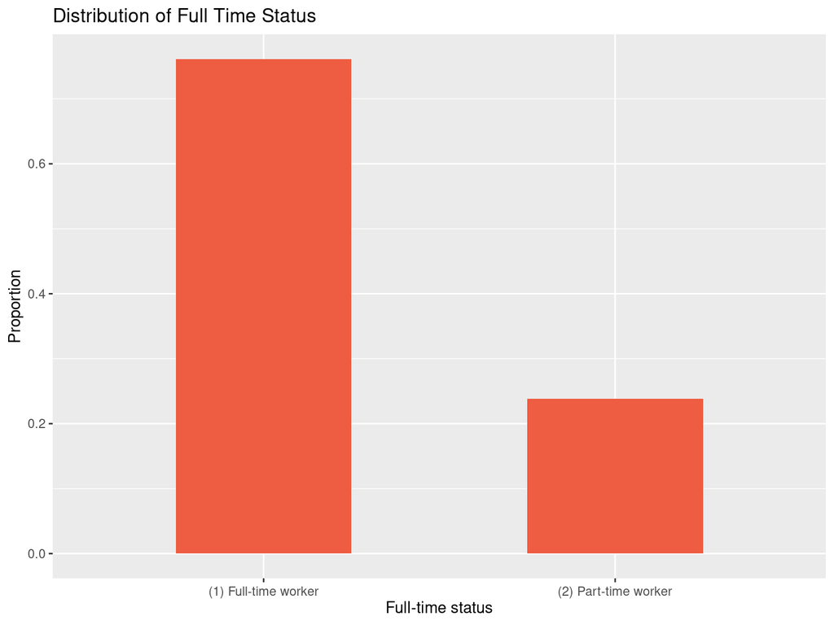

```
## [1] "(1) Full-time worker"
```

## Gender

Table 2. Distribution of Gender

| gender | n | prop |
| --- | --- | --- |
| (1) Male | 96 | 0.0227004 |
| (2) Female | 4133 | 0.9772996 |

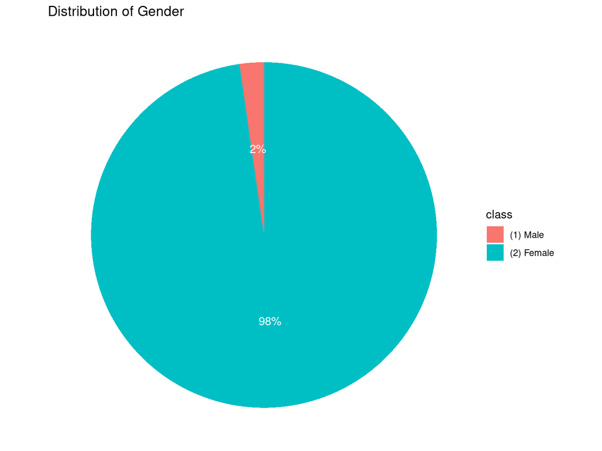

```
## [1] "(2) Female"
```

## Years of Experience

Table 3. Distribution of Years of Experience

| yrs_experience | n | prop |
| --- | --- | --- |
| (1) <=5 years | 1193 | 0.2816336 |
| (2) >5 to <=10 years | 962 | 0.2271010 |
| (3) >10 to <=15 years | 685 | 0.1617092 |
| (4) >15 to <=20 years | 576 | 0.1359773 |
| (5) >20 to <=25 years | 325 | 0.0767233 |
| (6) >25 years | 495 | 0.1168555 |

Table 4. Years of Experience Summary Table

| n | Mode | Median | Q1 | Q3 | IQR |
| --- | --- | --- | --- | --- | --- |
| 4236 | (1) <=5 years | (2) >5 to <=10 years | (1) <=5 years | (4) >15 to <=20 years | 3 |

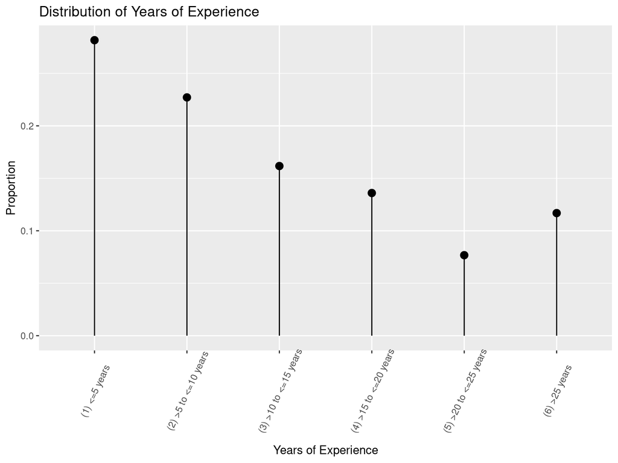

## Race

Table 5. Distribution of Race

| race | n | prop |
| --- | --- | --- |
| (1) White Only | 2607 | 0.6720804 |
| (2) Black or African American Only | 882 | 0.2273782 |
| (3) Asian Only | 186 | 0.0479505 |
| (8) Other | 204 | 0.0525909 |

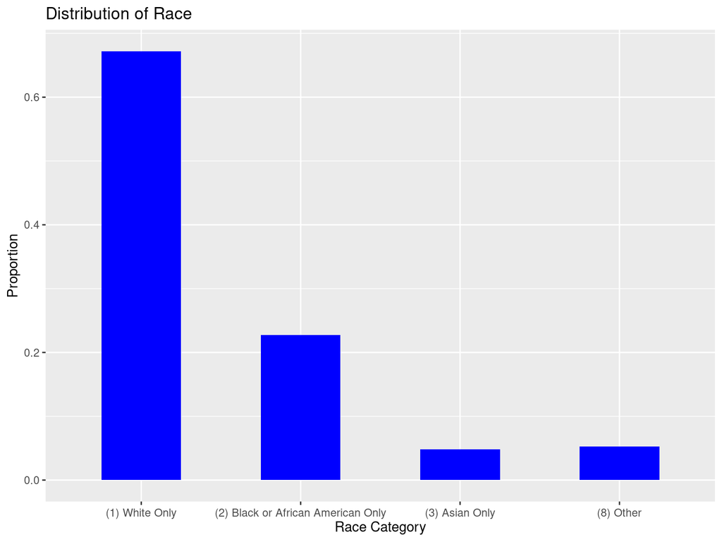

```
## [1] "(1) White Only"
```

## Hourly Wage

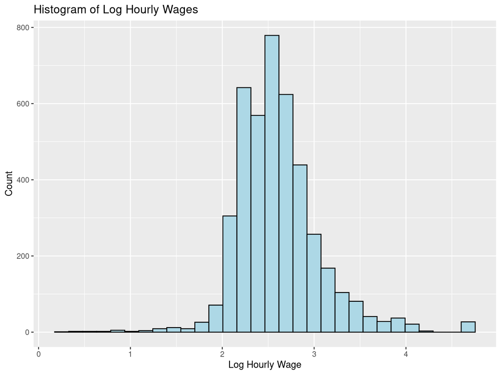

Table 6. Distribution of Log Hourly Wage

| n | Mean | Median | Min | Max | Range | SD | IQR |
| --- | --- | --- | --- | --- | --- | --- | --- |
| 4270 | 2.605759 | 2.551416 | 0.2513144 | 4.677491 | 4.426176 | 0.4542407 | 0.5007753 |

```
## [1] 2.302585
## attr(,"value.labels")
## named numeric(0)
```

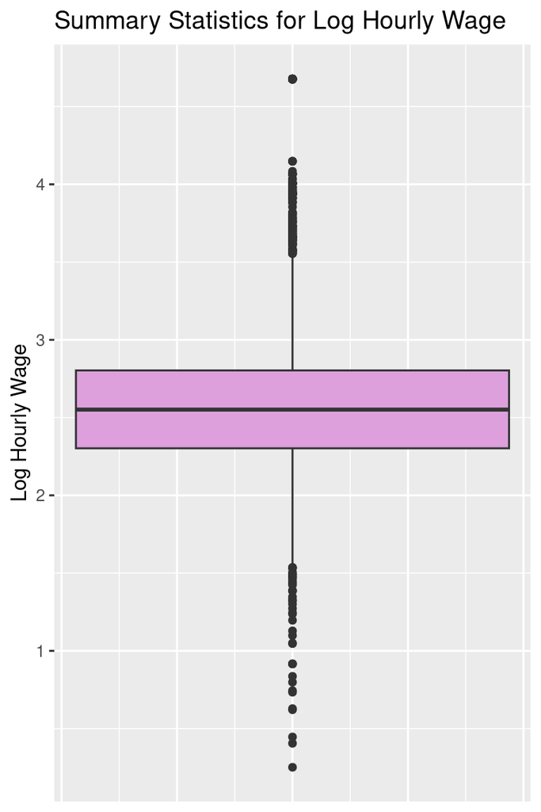

# 2. Exploring Associations

This section explores associations between hourly wages and race, and years of experience and gender.

## Hourly Wage vs. Race

Table 7. Contingency Table of Wage and Race

| race | n | mean_wage |
| --- | --- | --- |
| (1) White Only | 2607 | 15.50482 |
| (2) Black or African American Only | 882 | 13.66950 |
| (3) Asian Only | 186 | 17.54729 |
| (8) Other | 204 | 15.86995 |

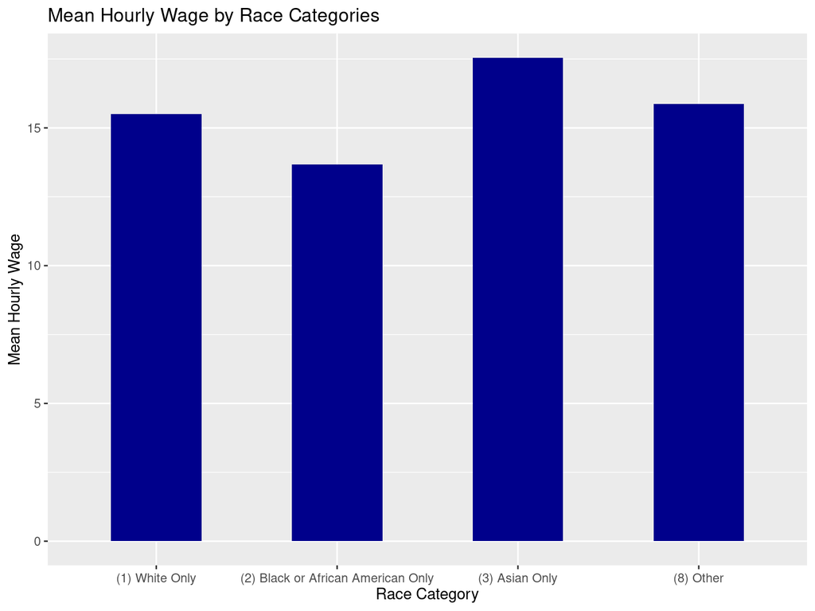

## Years of Experience vs. Gender

Table 8. Contingency Table of Years of Experience and Gender

| gender | yrs_experience | n | proportion |
| --- | --- | --- | --- |
| (1) Male | (1) <=5 years | 29 | 30.526316 |
| (1) Male | (2) >5 to <=10 years | 25 | 26.315790 |
| (1) Male | (3) >10 to <=15 years | 22 | 23.157895 |
| (1) Male | (4) >15 to <=20 years | 10 | 10.526316 |
| (1) Male | (5) >20 to <=25 years | 5 | 5.263158 |
| (1) Male | (6) >25 years | 4 | 4.210526 |
| (2) Female | (1) <=5 years | 1149 | 28.003900 |
| (2) Female | (2) >5 to <=10 years | 929 | 22.641969 |
| (2) Female | (3) >10 to <=15 years | 654 | 15.939556 |
| (2) Female | (4) >15 to <=20 years | 562 | 13.697295 |
| (2) Female | (5) >20 to <=25 years | 320 | 7.799171 |
| (2) Female | (6) >25 years | 489 | 11.918109 |

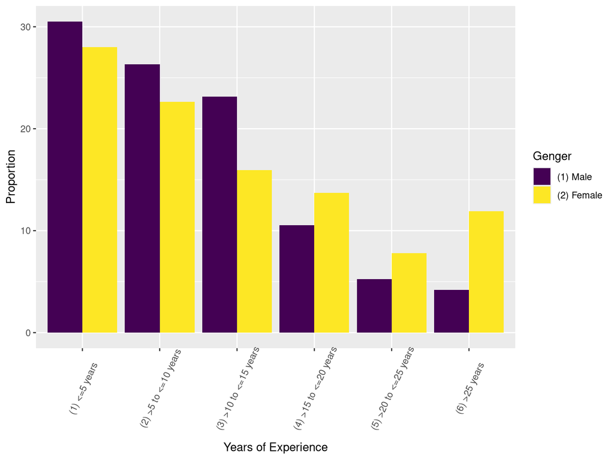

# 3. Linear Regression

This section estimates the following OLS regression model:

$log(Hourly Wage)=β_0+β_1 (Full Time)+β_2 (Female)+β_3…β_7 (Years of Experience categories)+ β_8 (Race categories)+ε$

**Regression Results**

|  | *Dependent variable:* |
| --- | --- |
|  | log_hr_wage |
| full_time_d | -0.01 |
|  | (0.02) |
| female_d | -0.15*** |
|  | (0.05) |
| exp_5to10_d | 0.16*** |
|  | (0.02) |
| exp_11to15_d | 0.26*** |
|  | (0.02) |
| exp_16to20_d | 0.30*** |
|  | (0.02) |
| exp_21to25_d | 0.39*** |
|  | (0.03) |
| exp_26plus_d | 0.37*** |
|  | (0.02) |
| black_d | -0.13*** |
|  | (0.02) |
| asian_d | 0.17*** |
|  | (0.03) |
| other_d | 0.04 |
|  | (0.03) |
| Constant | 2.58*** |
|  | (0.05) |
| Observations | 3,838 |
| R<sup>2</sup> | 0.12 |
| Adjusted R<sup>2</sup> | 0.12 |
| Residual Std. Error | 0.42 (df = 3827) |
| F Statistic | 52.30*** (df = 10; 3827) |
| *Note:* | p<0.1; p<0.05; p<0.01 |

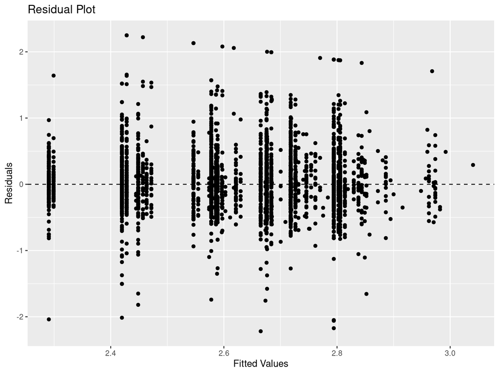

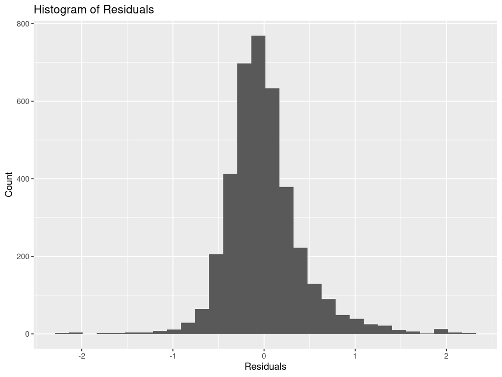